# **Spotify - Music Trends From 1956 to 2019**

### A data science project by Yufei Liu

## Introduction

Spotify provides users with digital music, podcasts and video services that make it easy to listen to millions of songs and watch other content from creators around the world. Users can discover, manage and share more than 82 million songs and more than 4 million podcasts for free. Or, users can upgrade to Spotify Premium, which gives them access to exclusive music features, including improved sound quality and an on-demand, offline and ad-free music listening experience. Spotify is available on a range of devices, including computers, phones, tablets, speakers, TVs and cars, and with Spotify Connect you can easily transition from one device to another. Today, Spotify is the world's most popular audio streaming subscription service with 422 million subscribers in 183 markets, including 182 million subscribers.

I really like use Spotify, and I also like listening music to relax myself during the free time. Therefore, I want to do a project about Spotify. After searching a lot of dataset, I decided to analyze the most popular genre based on the different decade. In my project, I will use the dataset "Spotify - All Time Top 2000s Mega Dataset" which contains audio statistics of roughly from between 1956 to 2019 on Spotify and describes the qualities of the top 2000 songs on Spotify as of 2019. In this project, I will focus on the following questions: which genres were more popular coming through 1950s to 2000s? Which factor will affect the popularity of a song? I believe these questions can help the musicians to improve their music and know what most people like in each decade, and it can also helps people to get more information about music history.

## Content Variables

- Index: ID
- Title: Name of the Track
- Artist: Name of the Artist
- Top Genre: Genre of the track
- Year: Release Year of the track
- Beats per Minute(BPM): The tempo of the song
- Energy: The energy of a song - the higher the value, the more energtic song.
- Danceability: The higher the value, the easier it is to dance to this song.
- Loudness: The higher the value, the louder the song.
- Valence: The higher the value, the more positive mood for the song.
- Length: The duration of the song.
- Acoustic: The higher the value the more acoustic the song is.
- Speechiness: The higher the value the more spoken words the song contains.
- Popularity: The higher the value the more popular the song is.

## Importing libraries

```python
import pandas as pd
import matplotlib.pyplot as plt
import numpy as np
import seaborn as sns
```

## Obtaining data

We import the data from csv file, and then take a look of dataset information and data types.

```python
# import the dataset from csv file
filepath = '/content/Spotify-2000.csv'
spotify = pd.read_csv(filepath)
spotify.head()
```

|  | Index | Title | Artist | Top Genre | Year | Beats Per Minute (BPM) | Energy | Danceability | Loudness (dB) | Liveness | Valence | Length (Duration) | Acousticness | Speechiness | Popularity |
| --- | --- | --- | --- | --- | --- | --- | --- | --- | --- | --- | --- | --- | --- | --- | --- |
| 0 | 1 | Sunrise | Norah Jones | adult standards | 2004 | 157 | 30 | 53 | -14 | 11 | 68 | 201 | 94 | 3 | 71 |
| 1 | 2 | Black Night | Deep Purple | album rock | 2000 | 135 | 79 | 50 | -11 | 17 | 81 | 207 | 17 | 7 | 39 |
| 2 | 3 | Clint Eastwood | Gorillaz | alternative hip hop | 2001 | 168 | 69 | 66 | -9 | 7 | 52 | 341 | 2 | 17 | 69 |
| 3 | 4 | The Pretender | Foo Fighters | alternative metal | 2007 | 173 | 96 | 43 | -4 | 3 | 37 | 269 | 0 | 4 | 76 |
| 4 | 5 | Waitin' On A Sunny Day | Bruce Springsteen | classic rock | 2002 | 106 | 82 | 58 | -5 | 10 | 87 | 256 | 1 | 3 | 59 |

```python
# check whether there is any null in the dataset
spotify.isnull().sum()
```

```
Index                     0
Title                     0
Artist                    0
Top Genre                 0
Year                      0
Beats Per Minute (BPM)    0
Energy                    0
Danceability              0
Loudness (dB)             0
Liveness                  0
Valence                   0
Length (Duration)         0
Acousticness              0
Speechiness               0
Popularity                0
dtype: int64
```

```python
# get the general information of the dataset
# know the type of each variables
spotify.info()
```

```
<class 'pandas.core.frame.DataFrame'>
RangeIndex: 1994 entries, 0 to 1993
Data columns (total 15 columns):
 #   Column                  Non-Null Count  Dtype
---  ------                  --------------  -----
 0   Index                   1994 non-null   int64
 1   Title                   1994 non-null   object
 2   Artist                  1994 non-null   object
 3   Top Genre               1994 non-null   object
 4   Year                    1994 non-null   int64
 5   Beats Per Minute (BPM)  1994 non-null   int64
 6   Energy                  1994 non-null   int64
 7   Danceability            1994 non-null   int64
 8   Loudness (dB)           1994 non-null   int64
 9   Liveness                1994 non-null   int64
 10  Valence                 1994 non-null   int64
 11  Length (Duration)       1994 non-null   object
 12  Acousticness            1994 non-null   int64
 13  Speechiness             1994 non-null   int64
 14  Popularity              1994 non-null   int64
dtypes: int64(11), object(4)
memory usage: 233.8+ KB
```

## Tidying and Modifying Data

After gaining a minimal understanding of the entire database, I try to clean up the data. I change the name of columns: Top Genre, Beats Per Minute (BPM), Loudness (dB), and Length (Duration). Because these names have spaces and parentheses, they may cause some problems in use. Also, I change the type of Title, Artist, Genre, Duration from Object to string for later use in data analysis.

```python
# change the name of some columns
spotify.rename(columns={'Top Genre': 'Genre',
                        'Beats Per Minute (BPM)': 'BPM',
                        'Loudness (dB)': 'dB',
                        'Length (Duration)': 'Duration',
                        }, inplace=True)
spotify.head()
```

|  | Index | Title | Artist | Genre | Year | BPM | Energy | Danceability | dB | Liveness | Valence | Duration | Acousticness | Speechiness | Popularity |
| --- | --- | --- | --- | --- | --- | --- | --- | --- | --- | --- | --- | --- | --- | --- | --- |
| 0 | 1 | Sunrise | Norah Jones | adult standards | 2004 | 157 | 30 | 53 | -14 | 11 | 68 | 201 | 94 | 3 | 71 |
| 1 | 2 | Black Night | Deep Purple | album rock | 2000 | 135 | 79 | 50 | -11 | 17 | 81 | 207 | 17 | 7 | 39 |
| 2 | 3 | Clint Eastwood | Gorillaz | alternative hip hop | 2001 | 168 | 69 | 66 | -9 | 7 | 52 | 341 | 2 | 17 | 69 |
| 3 | 4 | The Pretender | Foo Fighters | alternative metal | 2007 | 173 | 96 | 43 | -4 | 3 | 37 | 269 | 0 | 4 | 76 |
| 4 | 5 | Waitin' On A Sunny Day | Bruce Springsteen | classic rock | 2002 | 106 | 82 | 58 | -5 | 10 | 87 | 256 | 1 | 3 | 59 |

```python
# change the type of some columns
spotify['Title'] = spotify['Title'].astype('string')
spotify['Artist'] = spotify['Artist'].astype('string')
spotify['Genre'] = spotify['Genre'].astype('string')
spotify['Duration'] = spotify['Duration'].astype('string')
spotify.info()
```

```
<class 'pandas.core.frame.DataFrame'>
RangeIndex: 1994 entries, 0 to 1993
Data columns (total 15 columns):
 #   Column        Non-Null Count  Dtype
---  ------        --------------  -----
 0   Index         1994 non-null   int64
 1   Title         1994 non-null   string
 2   Artist        1994 non-null   string
 3   Genre         1994 non-null   string
 4   Year          1994 non-null   int64
 5   BPM           1994 non-null   int64
 6   Energy        1994 non-null   int64
 7   Danceability  1994 non-null   int64
 8   dB            1994 non-null   int64
 9   Liveness      1994 non-null   int64
 10  Valence       1994 non-null   int64
 11  Duration      1994 non-null   string
 12  Acousticness  1994 non-null   int64
 13  Speechiness   1994 non-null   int64
 14  Popularity    1994 non-null   int64
dtypes: int64(11), string(4)
memory usage: 233.8 KB
```

There are currently 149 genre categories, but there are many duplicate and overly detailed branches, so here I have divided them into 68 categories, which will reduce the possibility of duplication of categories while analyzing the data.

```python
# delete duplicate genre
# shorten the name of genre
new_genre = spotify['Genre'].copy()
while(max((new_genre.str.split(" ", 1)).str.len()) > 1):
  result = new_genre.str.split(" ",1)
  for i in range(len(result)):
      if (len(result[i]) > 1):
          result[i] = [result[i][1]]
  new_genre =  result.str.join('')
spotify['Genre'] = new_genre
spotify['Genre'].value_counts()
```

```
rock           856
pop            333
standards      123
metal           93
indie           77
              ...
laboratorio      1
holler           1
hardcore         1
trance           1
bebop            1
Name: Genre, Length: 68, dtype: int64
```

## Analyzing data

First, I sorted all the Popularity according to Genre, from here we can see that rock is the most popular Genre and ambient is the least popular Genre. Therefore, I guess rock will occupy the first position in many decades.

```python
# calculate the popularity score based on genre
# print the rank out
sort = spotify.groupby(['Genre']).sum().sort_values('Popularity')
sort[['Popularity']]
```

| Genre | Popularity |
| --- | --- |
| ambient | 28 |
| streektaal | 28 |
| rock-and-roll | 33 |
| j-core | 37 |
| hardcore | 37 |
| ... | ... |
| soul | 3032 |
| metal | 6141 |
| standards | 7697 |
| pop | 19390 |
| rock | 52025 |

68 rows × 1 columns

Based on the data we got from above, because the rock is the most popular genre, I want to know why the score will be pretty high. Therefore, I calculate the count of each genre, and I use the pie chart to show the result. Because we only need to show 5 data, the pie chart will be the most suitable graph to visualize. From here, we can see that rock is also the most frequent categories. Therefore, it might be the reason that it is the most popular genre.

*Resources*:

How to use pie chart in python: https://indianaiproduction.com/matplotlib-pie-chart/

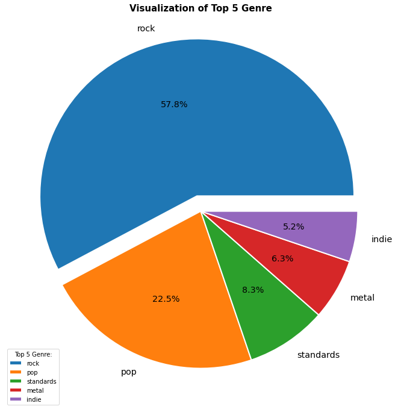

```python
# draw a pie chart of the top 5 genre
# because we only need 5 data here, we will use a graph to visualize it other than print it out
plt.figure(figsize = (16, 12))
values = spotify['Genre'].value_counts().head(5).values
names = spotify['Genre'].value_counts().head(5).index
explode = [0.1, 0, 0, 0, 0]
plt.pie(values, labels = names, autopct='%.1f%%', explode = explode,
        wedgeprops = { 'linewidth' : 2,'edgecolor' : "white" },
        textprops={'size': 'x-large'})
plt.legend(title = "Top 5 Genre:")
plt.title('Visualization of Top 5 Genre', fontsize = 15, fontweight = 'bold')
plt.show()
```

Then, I tried to find the relationship between year and popularity, but after plotting the images with scatterplot, I found that there is not much connection between popularity and year. Every year there are very popular songs and not so popular songs, and as the year increases, the polarization of song popularity starts to get worse.

```
(0.0, 104.45)
```

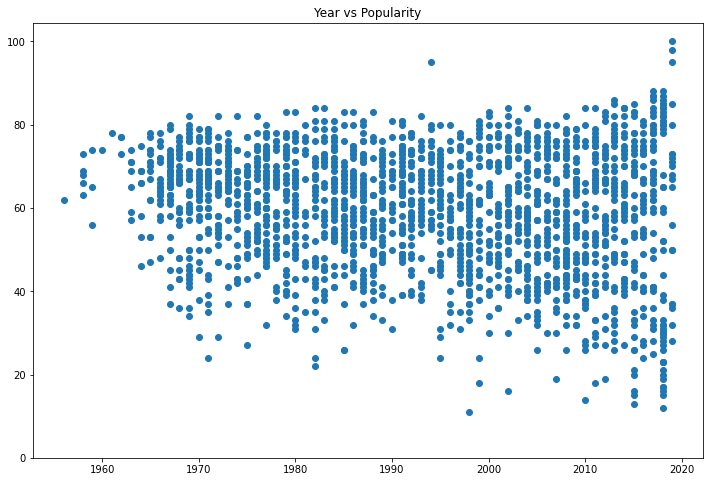

```python
# show the correlation between year and popularity
plt.figure(figsize = (12, 8))
plt.scatter(spotify['Year'], spotify['Popularity'])
plt.title("Year vs Popularity")
plt.ylim(0)
```

Then I divided the data by decade and put them into separate dataframes. I only need the Genre and Popularity data, because I will only compare them in this section to figure out which genres are the most popular in each decade.

```python
# seperate the data based on decade
sixties_data = spotify[(spotify.Year >1959) & (spotify.Year <1970)][['Genre', 'Popularity']]
seventies_data = spotify[(spotify.Year >1969) & (spotify.Year <1980)][['Genre', 'Popularity']]
eighties_data = spotify[(spotify.Year >1979) & (spotify.Year <1990)][['Genre', 'Popularity']]
nineties_data = spotify[(spotify.Year >1989) & (spotify.Year <2000)][['Genre', 'Popularity']]
thousands_data = spotify[(spotify.Year >1999) & (spotify.Year <2010)][['Genre', 'Popularity']]
tens_data = spotify[(spotify.Year >2009) & (spotify.Year <2020)][['Genre', 'Popularity']]
```

```python
print("The total song in 1960s is " + str(len(sixties_data)))
```

```
The total song in 1960s is 158
```

```python
print("The total song in 1970s is " + str(len(seventies_data)))
```

```
The total song in 1970s is 353
```

```python
print("The total song in 1980s is " + str(len(eighties_data)))
```

```
The total song in 1980s is 344
```

```python
print("The total song in 1990s is " + str(len(nineties_data)))
```

```
The total song in 1990s is 331
```

```python
print("The total song in 2000s is " + str(len(thousands_data)))
```

```
The total song in 2000s is 400
```

```python
print("The total song in 2010s is " + str(len(tens_data)))
```

```
The total song in 2010s is 399
```

I first counted the distribution of all the songs on the list in each decade and the total number, and we can guess that there was a very rapid shift in the songs of the 1960s and 1970s, probably because ideas became more open or listening devices were developed. This is because more than twice as many songs made the list in the 1970s as in the 1960s.

Then, I want to use violinplot to gain the general information of popularity over years and the popularity per song over years, because this kind of graph can give us the median and the probability of each part.

*Resources*:

How to use violinplot in python: https://seaborn.pydata.org/generated/seaborn.violinplot.html

```
[('1960s', 10138), ('1970s', 21932), ('1980s', 20450), ('1990s', 19685), ('2000s', 23190), ('2010s', 22705)]
```

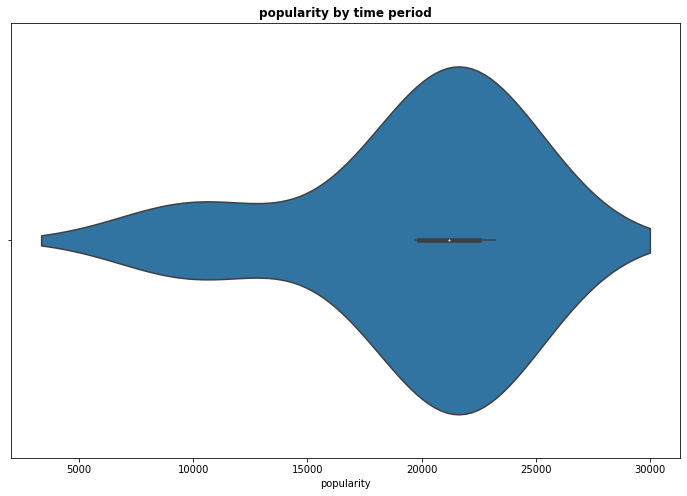

```python
# put the total popularity of each year into a new array
# the format is: (year, total popularity in this year)
# plot it in violinplot and analyze
total_data = []
total_data.append(('1960s', sixties_data.Popularity.sum()))
total_data.append(('1970s', seventies_data.Popularity.sum()))
total_data.append(('1980s', eighties_data.Popularity.sum()))
total_data.append(('1990s', nineties_data.Popularity.sum()))
total_data.append(('2000s', thousands_data.Popularity.sum()))
total_data.append(('2010s', tens_data.Popularity.sum()))
print(total_data)
plt.figure(figsize = (12, 8))
sns.violinplot(x=[x[1] for x in total_data])
plt.title('popularity by time period', fontweight = 'bold')
plt.xlabel('popularity')
plt.ylabel('')
plt.show()
```

Here, I use violinplot to show the popularity over time period, and the median is around 22000 in total each year, which is pretty high, and only 1960s is far from this number. Also, we can learn that the 2000s was the golden age of music, as the songs that ranked in the top 2000 were the most numerous and had the highest level of popularity at the same time.

```
[('1960s', 64.16455696202532), ('1970s', 62.13031161473088), ('1980s', 59.44767441860465), ('1990s', 59.47129909365559), ('2000s', 57.975), ('2010s', 56.904761904761905)]
```

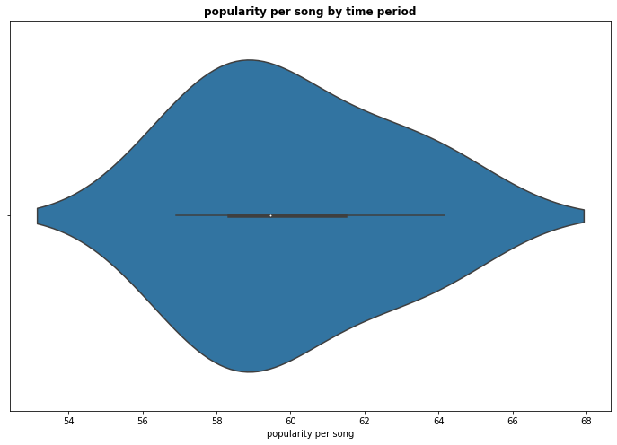

```python
# put the popularity per song of each year into a new array
# the format is: (year, popularity per song in this year)
# plot it in violinplot and analyze
single_data = []
single_data.append(('1960s', sixties_data.Popularity.sum()/len(sixties_data)))
single_data.append(('1970s', seventies_data.Popularity.sum()/len(seventies_data)))
single_data.append(('1980s', eighties_data.Popularity.sum()/len(eighties_data)))
single_data.append(('1990s', nineties_data.Popularity.sum()/len(nineties_data)))
single_data.append(('2000s', thousands_data.Popularity.sum()/len(thousands_data)))
single_data.append(('2010s', tens_data.Popularity.sum()/len(tens_data)))
print(single_data)
plt.figure(figsize = (12, 8))
sns.violinplot(x=[x[1] for x in single_data])
plt.title('popularity per song by time period', fontweight = 'bold')
plt.xlabel('popularity per song')
plt.ylabel('')
plt.show()
```

I divide the total popularity of each year by the total number in order to get the average popularity per song. The median is between 59 and 60, and we can conclude that more data is lower than the median from the graph. Moroever, although 1960 has the fewest songs, the quality is the highest, as the average popularity per song is the highest.

After analyzing the popularity over years, I will focus on the popularity of each genre in each genre. I will sum the popularity scores obtained for each genre and then represent them visually using a histogram.

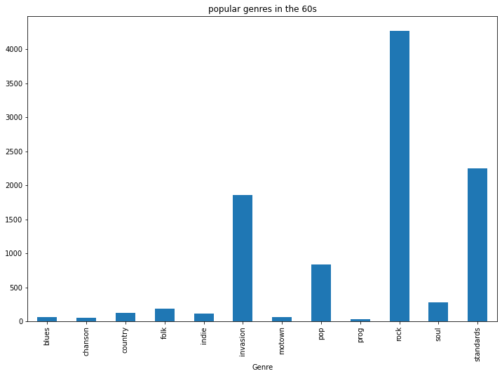

```python
# visualize the data in 1960s
plt.figure(figsize = (12, 8))
data = sixties_data.groupby(['Genre']).Popularity.sum()
data.plot(kind='bar')
plt.title('popular genres in the 60s')
```

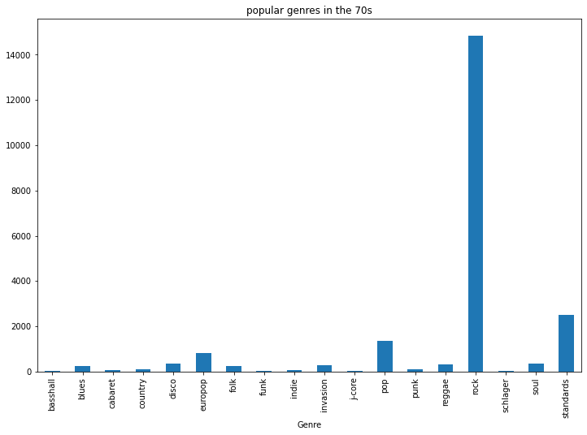

```python
# visualize the data in 1970s
plt.figure(figsize = (12, 8))
data = seventies_data.groupby(['Genre']).Popularity.sum()
data.plot(kind='bar')
plt.title('popular genres in the 70s')
```

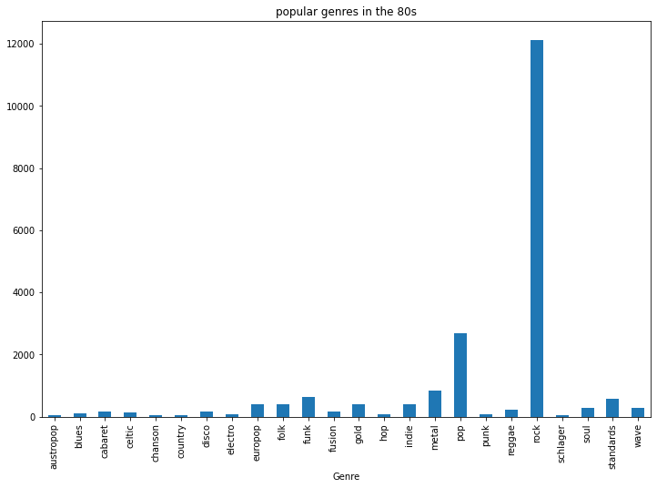

```python
# visualize the data in 1980s
plt.figure(figsize = (12, 8))
data = eighties_data.groupby(['Genre']).Popularity.sum()
data.plot(kind='bar')
plt.title('popular genres in the 80s')
```

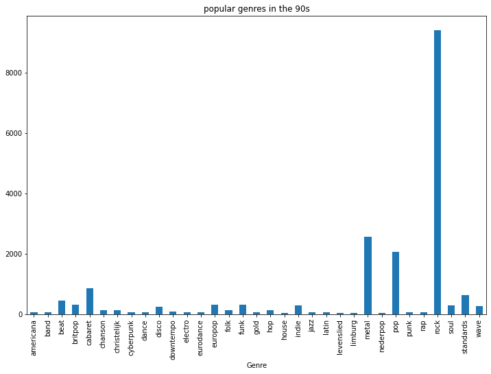

```python
# visualize the data in 1990s
plt.figure(figsize = (12, 8))
data = nineties_data.groupby(['Genre']).Popularity.sum()
data.plot(kind='bar')
plt.title('popular genres in the 90s')
```

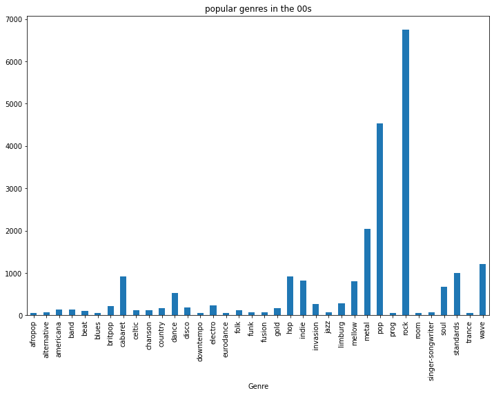

```python
# visualize the data in 2000s
plt.figure(figsize = (12, 8))
data = thousands_data.groupby(['Genre']).Popularity.sum()
data.plot(kind='bar')
plt.title('popular genres in the 00s')
```

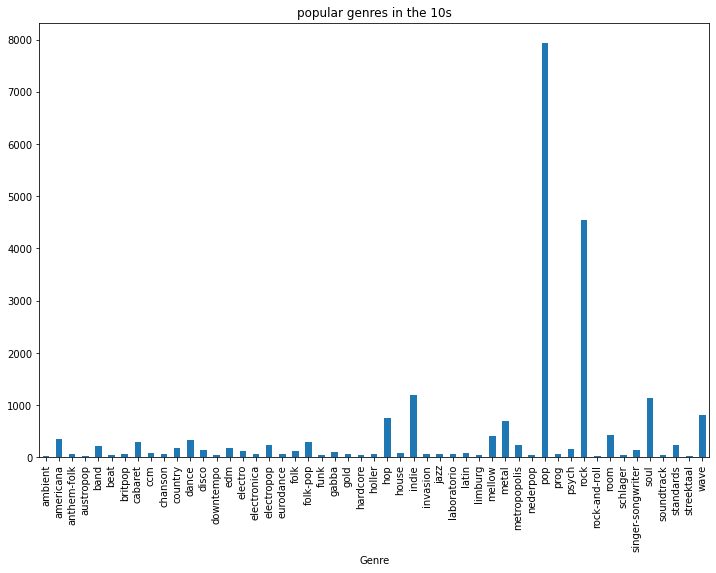

```python
# visualize the data in 2010s
plt.figure(figsize = (12, 8))
data = tens_data.groupby(['Genre']).Popularity.sum()
data.plot(kind='bar')
plt.title('popular genres in the 10s')
```

I use histogram to visual the data because people can easily compare the height of each genre to conclude the most popular one. If we choose pie chart, it is hard for us to determine the top one based on the graph if there are some similar data. If we simply print the data out, people can not see the result visually, which is not good approach.

*Resources*:

How to use histogram in python: https://www.geeksforgeeks.org/plotting-histogram-in-python-using-matplotlib/

From this visualization, we can conclude that album rock is the most popular genre in 60's, 70's, 80's, 90's and 00's, pop is the most popular genre in 10's. This is the same result as I predicted at the beginning, rock occupied the number one position for many eras until the 10's when it was replaced by pop. At the same time, we can feel from the histogram that the categories are growing more and more every year, and that there are various new types of music being created.

After identified the most popular categories for each era, I wanted to focus on analyzing the factors that influence popularity. So, first I will I use the heatmap to calculate the exact correlation between factors, and then plot the scatterplot for each possible factor (numeric data) and determine the correlation between the two data based on the image. I use heatmap because I can easily see the corraltion between two variables through the color.

*Resources*:

How to use heatmap in python: https://seaborn.pydata.org/generated/seaborn.heatmap.html

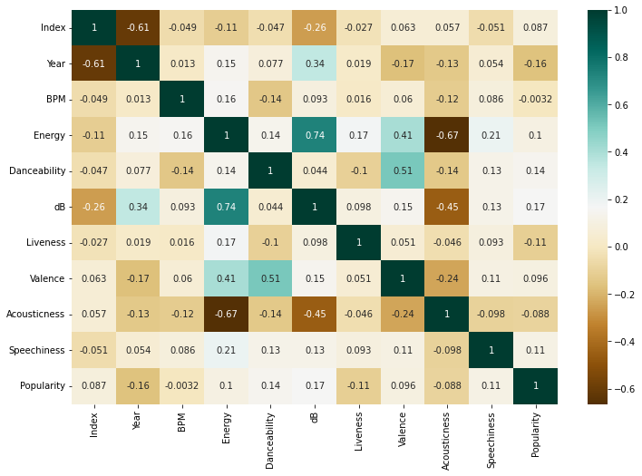

```python
# show the exact correlation between factors
plt.figure(figsize = (12, 8))
sns.heatmap(spotify.corr(),annot=True,cmap='BrBG')
plt.show()
```

*Resources*:

How to use scatterplot in python: https://www.w3schools.com/python/python_ml_scatterplot.asp

```
(0.0, 104.45)
```

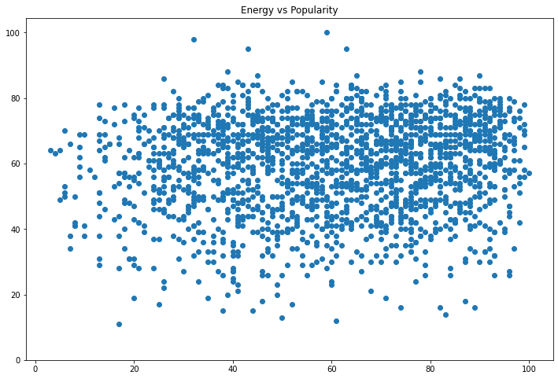

```python
# show the correlation between energy and popularity
plt.figure(figsize = (12, 8))
plt.scatter(spotify['Energy'], spotify['Popularity'])
plt.title("Energy vs Popularity")
plt.ylim(0)
```

```
(0.0, 104.45)
```

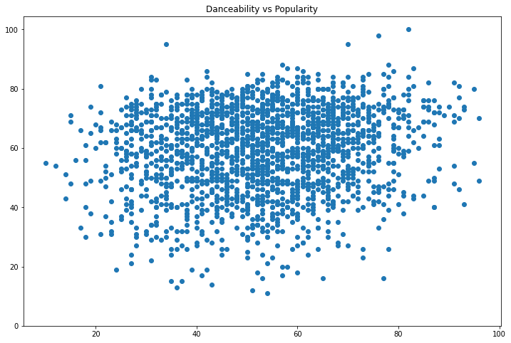

```python
# show the correlation between danceability and popularity
plt.figure(figsize = (12, 8))
plt.scatter(spotify['Danceability'], spotify['Popularity'])
plt.title("Danceability vs Popularity")
plt.ylim(0)
```

```
(0.0, 104.45)
```

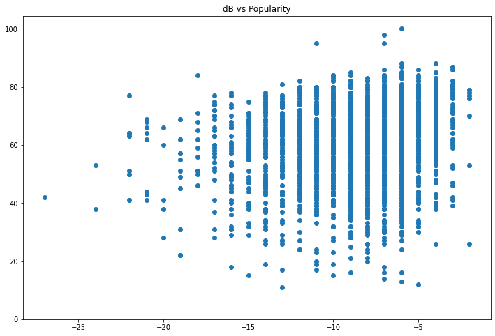

```python
# show the correlation between loudness and popularity
plt.figure(figsize = (12, 8))
plt.scatter(spotify['dB'], spotify['Popularity'])
plt.title("dB vs Popularity")
plt.ylim(0)
```

```
(0.0, 104.45)
```

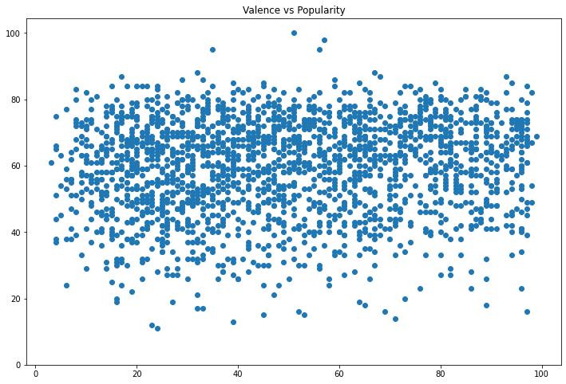

```python
# show the correlation between valence and popularity
plt.figure(figsize = (12, 8))
plt.scatter(spotify['Valence'], spotify['Popularity'])
plt.title("Valence vs Popularity")
plt.ylim(0)
```

```
-5.042261113618105e-07
```

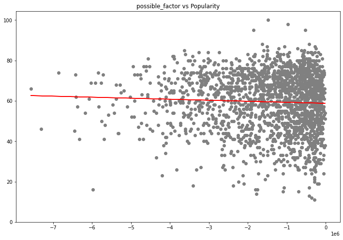

```python
# create a new variable with the multiplication of these four factors
# then find the slope and intercept
# draw it in the scatter plot
spotify['possible_factor'] = spotify['Energy'] * spotify['dB'] * spotify['Danceability'] * spotify['Valence']
plt.figure(figsize = (12, 8))
plt.scatter(spotify['possible_factor'], spotify['Popularity'], color = 'grey')
plt.title("possible_factor vs Popularity")
plt.ylim(0)
m,b = np.polyfit(spotify['possible_factor'], spotify['Popularity'], 1)
print(m)
plt.plot(spotify['possible_factor'], m*spotify['possible_factor'] + b, color = 'red')
```

Through this image, we can see that there is a weak negative correlation between possible factors and popularity. So, we can probably conclude that the popularity of a song has a very weak relationship with its audio features like Danceability, Loudness, Danceability, Valence (Positivity).

Because the above combination brought less than ideal results, I recombined them according to the correlation between these four factors.

```
0.006518607967941658
```

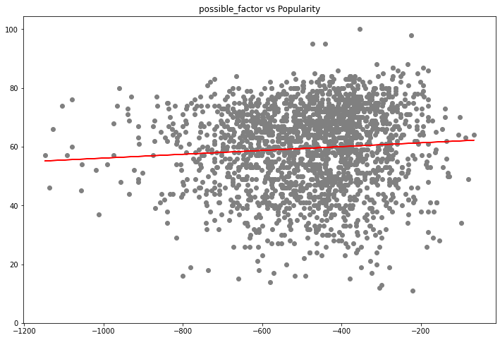

```python
# create a new variable with the multiplication of energy and dB
# then find the slope and intercept
# draw it in the scatter plot
spotify['possible_factor'] = spotify['Energy'] * spotify['dB']
plt.figure(figsize = (12, 8))
plt.scatter(spotify['possible_factor'], spotify['Popularity'], color = 'grey')
plt.title("possible_factor vs Popularity")
plt.ylim(0)
m,b = np.polyfit(spotify['possible_factor'], spotify['Popularity'], 1)
print(m)
plt.plot(spotify['possible_factor'], m*spotify['possible_factor'] + b, color = 'red')
```

```
0.0009146959530916145
```

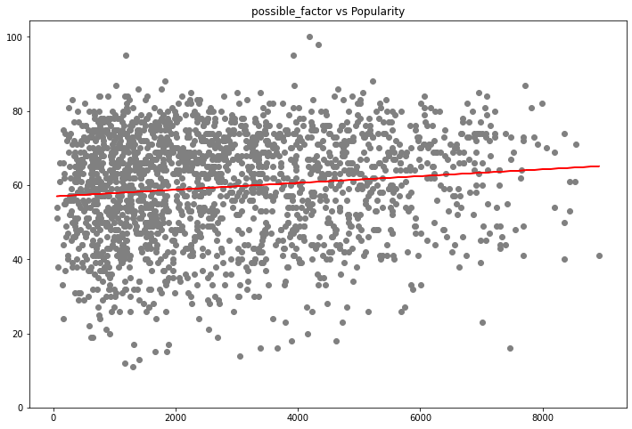

```python
# create a new variable with the multiplication of danceability and valence
# then find the slope and intercept
# draw it in the scatter plot
spotify['possible_factor'] = spotify['Danceability'] * spotify['Valence']
plt.figure(figsize = (12, 8))
plt.scatter(spotify['possible_factor'], spotify['Popularity'], color = 'grey')
plt.title("possible_factor vs Popularity")
plt.ylim(0)
m,b = np.polyfit(spotify['possible_factor'], spotify['Popularity'], 1)
print(m)
plt.plot(spotify['possible_factor'], m*spotify['possible_factor'] + b, color = 'red')
```

```
0.0036964084768666204
```

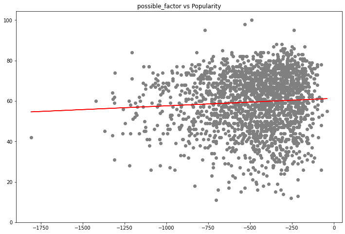

```python
# create a new variable with the multiplication of dB and danceability
# then find the slope and intercept
# draw it in the scatter plot
spotify['possible_factor'] = spotify['dB'] * spotify['Danceability']
plt.figure(figsize = (12, 8))
plt.scatter(spotify['possible_factor'], spotify['Popularity'], color = 'grey')
plt.title("possible_factor vs Popularity")
plt.ylim(0)
m,b = np.polyfit(spotify['possible_factor'], spotify['Popularity'], 1)
print(m)
plt.plot(spotify['possible_factor'], m*spotify['possible_factor'] + b, color = 'red')
```

According to the above picture, we can see that all three sets of data and popularity have weak positive correlation and their slopes are even greater than when all of them are combined. The highest correlation is loudness with 0.17, and it might be the most possible factor to affect the popularity.

## Conclusion

In the article, I explain all the visualization methods I use and why I use this graph to present my results. I have also provided many links for my readers to learn more. I hope that this tutorial will not only give them an insight into the history of popular music, but also teach them how to analyze data well.